# M2 Lab

Matthew Præstgaard

Spring 2024

## Libraries and Functions

```r
library(tidyverse) # for data manipulation
library(psych) # for pairiwse scatter plot function (not necessary but in case you want to use that function from the lecture code)
library(car) # for extra model diagnostics like plots and vif() function
library(MASS) # for rlm() function (robust regression)
library(plotly)
library(ggthemr)
ggthemr("flat dark")
library(gridExtra)
library(ggh4x)
library(kableExtra)
library(jtools)
library(rlang)
library(here)
library(skimr)
library(corrplot)
library(broom)
```

```r
# Function to summarize variables with optional grouping
# Usage: summarize.var(dataset, var, group_var (optional))
summarize.var <- function(dataset, var, group_var) {
  require(tidyverse)
  require(rlang)

  result <- dataset %>%
    group_by({{ group_var }}) %>%
    summarise(
      mean = mean({{ var }}, na.rm = TRUE),
      median = median({{ var }}, na.rm = TRUE),
      min = min({{ var }}, na.rm = TRUE),
      max = max({{ var }}, na.rm = TRUE),
      q25 = quantile({{ var }}, 0.25, na.rm = TRUE), # first quartile
      q75 = quantile({{ var }}, 0.75, na.rm = TRUE), # third quartile
      sd = sd({{ var }}, na.rm = TRUE),
      n = length(na.omit({{ var }}))
    ) %>%
    mutate(IQR = q75 - q25)

  return(result)
}
```

```r
library(ggplot2)

ggResid <- function(fit) {
  # Extract fitted values and residuals from the linear model
  fitted_values <- fit$fitted.values
  residuals <- fit$residuals

  # Create a data frame for the residuals vs. fitted values plot
  resid_data <- data.frame(Fitted = fitted_values, Residuals = residuals)

  # Create the plot
  ggplot(resid_data, aes(x = Fitted, y = Residuals)) +
    geom_point() +
    geom_hline(yintercept = 0, color = "red", linetype = "dashed") +
    labs(
      title = "Residuals vs. Fitted Values",
      x = "Fitted Values",
      y = "Residuals"
    )
}

# Example usage:
# fit <- lm(mpg ~ disp + hp, data = mtcars)
# ggResid(fit)
```

```r
# ggplotRegression
# use to plot linear model with summary statistics and error
# Usage: ggplotRegression(data)
ggRegression <- function(fit, title = "title") {
  require(ggplot2)

  ggplot(fit$model, aes_string(x = names(fit$model)[2], y = names(fit$model)[1])) +
    geom_point() +
    stat_smooth(
      method = "lm",
      geom = "smooth"
    ) +
    labs(
      title = title,
      subtitle = paste(
        "Adj R2 = ", signif(summary(fit)$adj.r.squared, 5),
        "Intercept =", signif(fit$coef[[1]], 5),
        " Slope =", signif(fit$coef[[2]], 5),
        " P =", signif(summary(fit)$coef[2, 4], 5)
      )
    )
}
```

```r
qqTest <- function(data, sample, title = "title", facet_var = NULL) {
  require(tidyverse)

  gg <- ggplot(
    data,
    aes(sample = {{ sample }})
  ) +
    stat_qq() +
    stat_qq_line(
      size = 0.8,
    ) +
    labs(
      title = title,
      x = "Theoretical Quantiles",
      y = "Sample Quantiles"
    ) +
    guides(color = "none")

  if (!is.null(facet_var)) {
    # Extract colors from facet_var variable
    colors <- pull(data, {{ facet_var }})

    gg <- gg + aes(color = factor(colors)) + facet_wrap(as.formula(paste("~", facet_var)))
  }

  return(gg)
}
```

```r
# density plots with optional grouping variable
# can be faceted or together by specifying either group or color
# usage: density.dodge(data, sample, group = "group" (optional), color = "NULL" (optional), title = "title" (optional) )
ggDensity <- function(data, sample, group = NULL, color = NULL, title = "Insert Title") {
  require(ggplot2)

  plot <- ggplot(data, aes(x = {{ sample }})) +
    geom_density() +
    labs(
      title = title,
      y = "Frequency",
      color = NULL
    )

  if (!is.null(group)) {
    colors <- pull(data, {{ group }})

    plot <- plot + aes(color = factor(colors)) +
      facet_wrap(as.formula(paste("~", group))) +
      labs(color = "Group")
  }

  if (!is.null(color)) {
    colors <- pull(data, {{ color }})

    plot <- plot + aes(fill = factor(colors), color = factor(colors), alpha = 0.02) +
      labs(fill = "Group") +
      geom_density(size = 1) +
      guides(color = "none", alpha = "none")
  }

  return(plot)
}
```

# Data Management

We will use these data to model the relationship between toluene exposure and blood concentration, possibly adjusting for other variables.

```r
setwd("Lab2")
```

```
## Error in setwd("Lab2"): cannot change working directory
```

```r
# reading data and making factor variable for snout size
data <- read_csv("hwdata2.csv") %>%
  mutate(
    snout_f = factor(snoutsize - 1,
      levels = c(0, 1),
      labels = c("short", "long")
    ),
    snoutsize = as.factor(snoutsize)
  )
```

# Part 1) Visualize data

**Calculate some descriptive statistics and display some plots to learn about the data.** (You don’t have to do extensive summaries/plots, but get a sense of the types of variables, any missingness, distribution of certain variables that could be important in the regression models, and relationships between variables). You should create a factor variable for snout size.

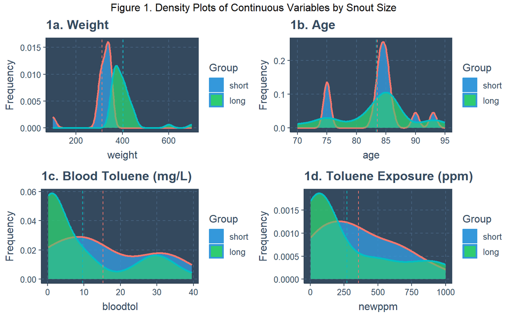

```r
weightStats <- summarize.var(data, weight, snout_f) %>%
  mutate_if(is.numeric, round, digits = 2)
ageStats <- summarize.var(data, age, snout_f) %>%
  mutate_if(is.numeric, round, digits = 2)
bloodStats <- summarize.var(data, bloodtol, snout_f) %>%
  mutate_if(is.numeric, round, digits = 2)
ppmStats <- summarize.var(data, newppm, snout_f) %>%
  mutate_if(is.numeric, round, digits = 2)

weightplot <- ggDensity(data, weight, color = "snout_f", title = "1a. Weight") + geom_vline(aes(xintercept = mean, color = snout_f), data = weightStats, linetype = "dashed")
ageplot <- ggDensity(data, age, color = "snout_f", title = "1b. Age") + geom_vline(aes(xintercept = mean, color = snout_f), data = ageStats, linetype = "dashed")
bloodplot <- ggDensity(data, bloodtol, color = "snout_f", title = "1c. Blood Toluene (mg/L)") + geom_vline(aes(xintercept = mean, color = snout_f), data = bloodStats, linetype = "dashed")
newppmplot <- ggDensity(data, newppm, color = "snout_f", title = "1d. Toluene Exposure (ppm)") + geom_vline(aes(xintercept = mean, color = snout_f), data = ppmStats, linetype = "dashed")

grid.arrange(
  weightplot, ageplot, bloodplot, newppmplot,
  nrow = 2, ncol = 2,
  top = "Figure 1. Density Plots of Continuous Variables by Snout Size"
)
```

```r
# ggpubr::ggdensity(data, x = "weight", add = "mean", rug = TRUE, color = "snout_f", fill = "snout_f") %>% ggplotly()

# pWeight <- ggplotly(weightplot)
# pAge <- ggplotly(ageplot)
# pBlood <- ggplotly(bloodplot)
# pPPM <- ggplotly(newppmplot)

# subplot(pWeight, pAge, pBlood, pPPM, nrows = 2)

skimr::skim(data)
```

Data summary

| Name | data |
| --- | --- |
| Number of rows | 60 |
| Number of columns | 7 |
| _______________________ |  |
| Column type frequency: |  |
| factor | 2 |
| numeric | 5 |
| ________________________ |  |
| Group variables | None |

**Variable type: factor**

| skim_variable | n_missing | complete_rate | ordered | n_unique | top_counts |
| --- | --- | --- | --- | --- | --- |
| snoutsize | 0 | 1 | FALSE | 2 | 2: 45, 1: 15 |
| snout_f | 0 | 1 | FALSE | 2 | lon: 45, sho: 15 |

**Variable type: numeric**

| skim_variable | n_missing | complete_rate | mean | sd | p0 | p25 | p50 | p75 | p100 | hist |
| --- | --- | --- | --- | --- | --- | --- | --- | --- | --- | --- |
| rat | 0 | 1 | 30.50 | 17.46 | 1.00 | 15.75 | 30.50 | 45.25 | 60.00 | ▇▇▇▇▇ |
| bloodtol | 0 | 1 | 11.00 | 12.62 | 0.22 | 0.70 | 6.54 | 22.07 | 39.54 | ▇▃▁▂▂ |
| weight | 0 | 1 | 380.55 | 72.71 | 100.00 | 350.25 | 373.50 | 406.00 | 700.00 | ▁▂▇▁▁ |
| age | 0 | 1 | 83.40 | 5.70 | 70.00 | 82.25 | 85.00 | 86.00 | 95.00 | ▃▂▇▅▂ |
| newppm | 0 | 1 | 292.48 | 311.99 | 3.57 | 50.70 | 104.50 | 502.50 | 1000.00 | ▇▂▂▂▂ |

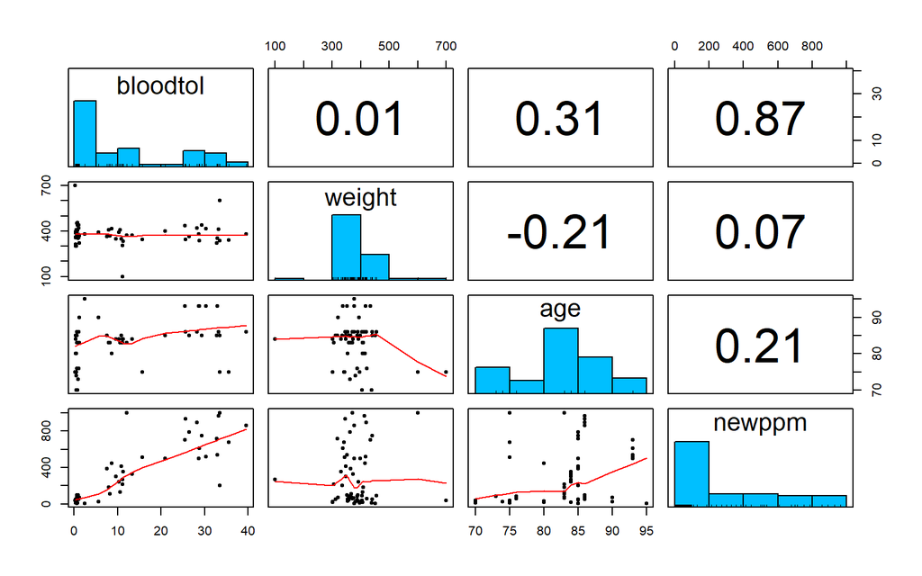

```r
pairs.panels(data[, c("bloodtol", "weight", "age", "newppm")],
  ellipses = FALSE, density = FALSE, hist.col = "deepskyblue"
)
```

Much of the data appear to be skewed and multimodal, although weight is much less so than the other continuous variables. There were no missing values.

# Part 2) SLR

**Fit a regression model for blood toluene (bloodtol) that contains only toluene exposure (newppm) as a predictor and perform a graphical analysis to assess the linearity, equal variance, and normality assumptions of linear regression.** **Interpret the plots and evaluate if you believe the assumptions are met.**

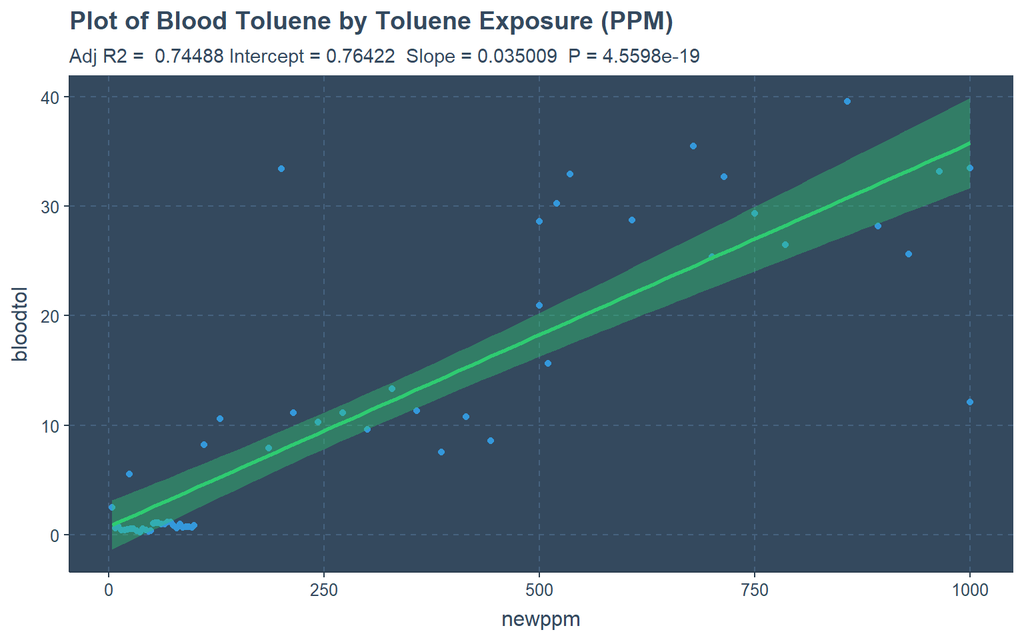

```r
# fit slr model
bloodPPM <- lm(bloodtol ~ newppm, data = data)

ggRegression(bloodPPM, title = "Plot of Blood Toluene by Toluene Exposure (PPM)")
```

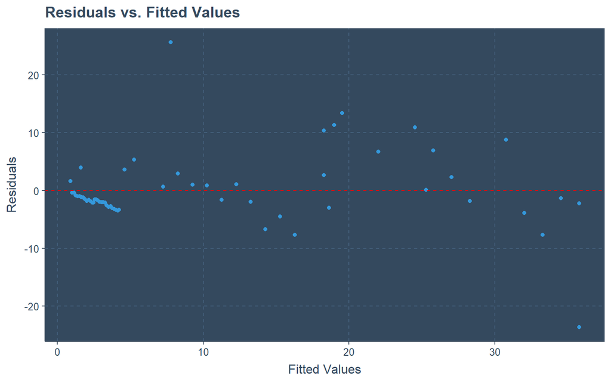

```r
ggResid(bloodPPM)
```

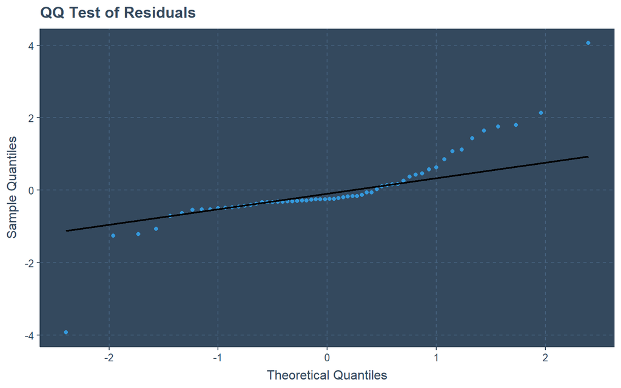

```r
qqTest(bloodPPM, .stdresid, title = "QQ Test of Residuals")
```

```r
# plot residual vs fitted and residual qq-plot
# hint: if you've saved your model above you can use the plot() function and specify which = 1:2 to tell R to only print the first 2 plots
```

Interpretation of plots/evaluation of assumptions:  
The plot of the residuals shows a pattern, especially at the beginning, rather than being random-appearing, suggesting potential violation of linearity. The spread of residuals also appears to further deviate from the line as the fitted values go up, suggesting possible unequal variance. The QQ-plot of the residuals suggests that they may not be normally distributed and have heavy tails.

# Part 3) MLR

**We will now add the other covariates to the model. Assess which variables appear to be important and explicitly** **test if there is effect modification (interaction) of toluene exposure by weight, age, or snout size.**

```r
# model with interactions included
full_model <- lm(bloodtol ~ newppm + weight + age + snout_f, data = data)
# test if the interactions are useful (you can just tun one test to test them all at once)
summary(full_model)
```

```
##
## Call:
## lm(formula = bloodtol ~ newppm + weight + age + snout_f, data = data)
##
## Residuals:
##      Min       1Q   Median       3Q      Max
## -21.2982  -2.5936  -0.6433   2.0629  22.7613
##
## Coefficients:
##               Estimate Std. Error t value Pr(>|t|)
## (Intercept) -25.190637  14.283095  -1.764   0.0833 .
## newppm        0.033114   0.002732  12.122   <2e-16 ***
## weight        0.007849   0.013948   0.563   0.5759
## age           0.312591   0.150875   2.072   0.0430 *
## snout_flong  -3.397497   2.274375  -1.494   0.1409
## ---
## Signif. codes:  0 '***' 0.001 '**' 0.01 '*' 0.05 '.' 0.1 ' ' 1
##
## Residual standard error: 6.201 on 55 degrees of freedom
## Multiple R-squared:  0.7749, Adjusted R-squared:  0.7585
## F-statistic: 47.32 on 4 and 55 DF,  p-value: < 2.2e-16
```

```r
interaction_model <- lm(bloodtol ~ newppm * weight + newppm * age + newppm * snout_f, data = data)
summary(interaction_model)
```

```
##
## Call:
## lm(formula = bloodtol ~ newppm * weight + newppm * age + newppm *
##     snout_f, data = data)
##
## Residuals:
##      Min       1Q   Median       3Q      Max
## -18.4224  -3.2132  -0.5186   1.6325  23.0298
##
## Coefficients:
##                      Estimate Std. Error t value Pr(>|t|)
## (Intercept)        -8.030e+00  1.924e+01  -0.417    0.678
## newppm             -4.737e-02  5.771e-02  -0.821    0.415
## weight             -6.331e-04  1.822e-02  -0.035    0.972
## age                 1.354e-01  2.013e-01   0.673    0.504
## snout_flong        -2.440e+00  3.423e+00  -0.713    0.479
## newppm:weight       4.064e-05  4.522e-05   0.899    0.373
## newppm:age          8.146e-04  5.727e-04   1.422    0.161
## newppm:snout_flong -5.339e-03  7.880e-03  -0.678    0.501
##
## Residual standard error: 6.251 on 52 degrees of freedom
## Multiple R-squared:  0.7837, Adjusted R-squared:  0.7546
## F-statistic: 26.92 on 7 and 52 DF,  p-value: 3.498e-15
```

```r
# anova_comparison <- anova(full_model, interaction_model)
# summary(anova_comparison)
```

# Part 4) Collinearity

**Check for collinearity between the 4 covariates (exposure, age, weight, snout size).** **Are you concerned that collinearity could be affecting our statistical inference in these data?**

```r
# measure of collinearity in the model involving exposure, weight, age, and snout size
vif(full_model)
```

```
##   newppm   weight      age  snout_f
## 1.114512 1.578022 1.135562 1.513262
```

```r
# also testing a model without weight and snout length (just the significant variables from the partial F-test)
newppmAge <- lm(bloodtol ~ newppm + age, data = data)
summary(newppmAge)
```

[output not shown]

```
##
## Call:
## lm(formula = bloodtol ~ newppm + age, data = data)
##
## Residuals:
##      Min       1Q   Median       3Q      Max
## -22.7955  -2.7982  -0.9977   1.8156  25.0754
##
## Coefficients:
##               Estimate Std. Error t value Pr(>|t|)
## (Intercept) -22.789938  12.003603  -1.899   0.0627 .
## newppm        0.033909   0.002655  12.771   <2e-16 ***
## age           0.286279   0.145273   1.971   0.0536 .
## ---
## Signif. codes:  0 '***' 0.001 '**' 0.01 '*' 0.05 '.' 0.1 ' ' 1
##
## Residual standard error: 6.221 on 57 degrees of freedom
## Multiple R-squared:  0.7652, Adjusted R-squared:  0.757
## F-statistic: 92.88 on 2 and 57 DF,  p-value: < 2.2e-16
```

```r
vif(newppmAge)
```

```
##   newppm      age
## 1.046181 1.046181
```

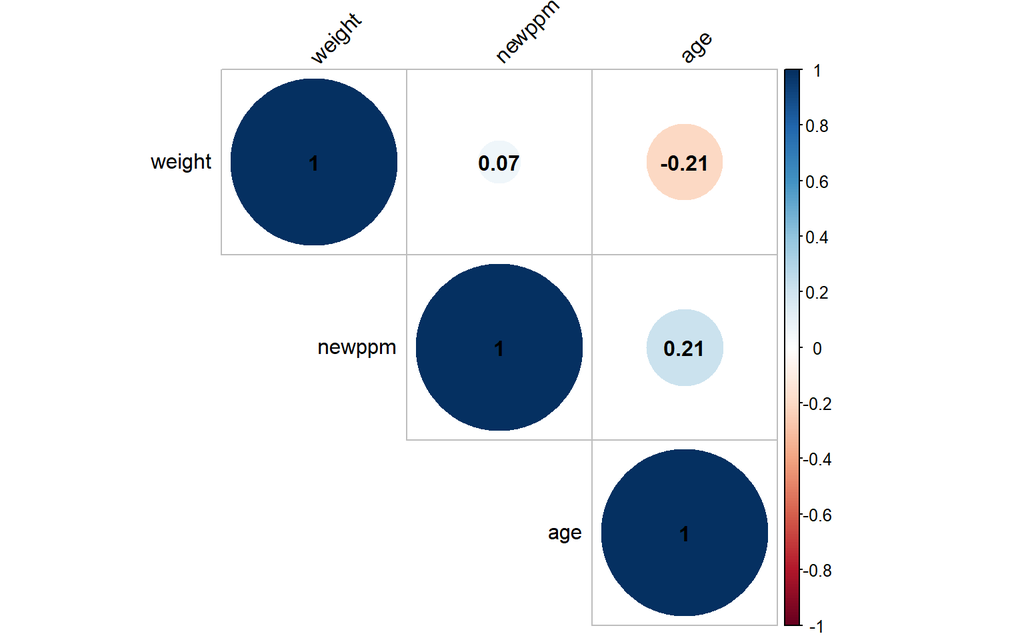

```r
# their coefficients did not change much

# making a correlation matrix
cor_matrix <- cor(data[, c("newppm", "weight", "age")], use = "complete.obs")

corrplot(cor_matrix,
  method = "circle", type = "upper", order = "hclust",
  tl.col = "black", tl.srt = 45, addCoef.col = "black"
)
```

# Part 5) Choose a Model

**Based on your analysis so far, choose the model that you believe is the best. Use this as your final model. Justify why you chose this model and comment on any potential assumption violations in this model (a few residual plots may be helpful for this).**

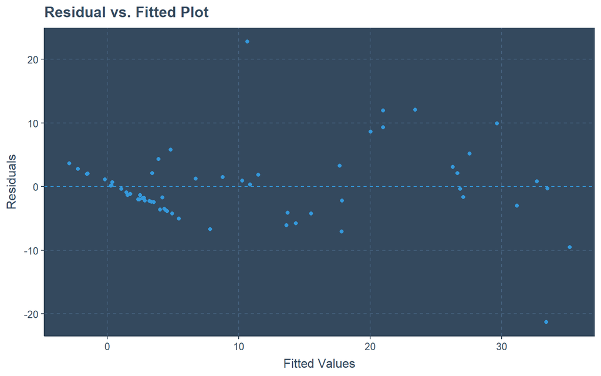

```r
# Residual vs. Fitted Plot
ggplot(full_model, aes(.fitted, .resid)) +
  geom_point() +
  geom_hline(yintercept = 0, linetype = "dashed") +
  labs(x = "Fitted Values", y = "Residuals", title = "Residual vs. Fitted Plot")
```

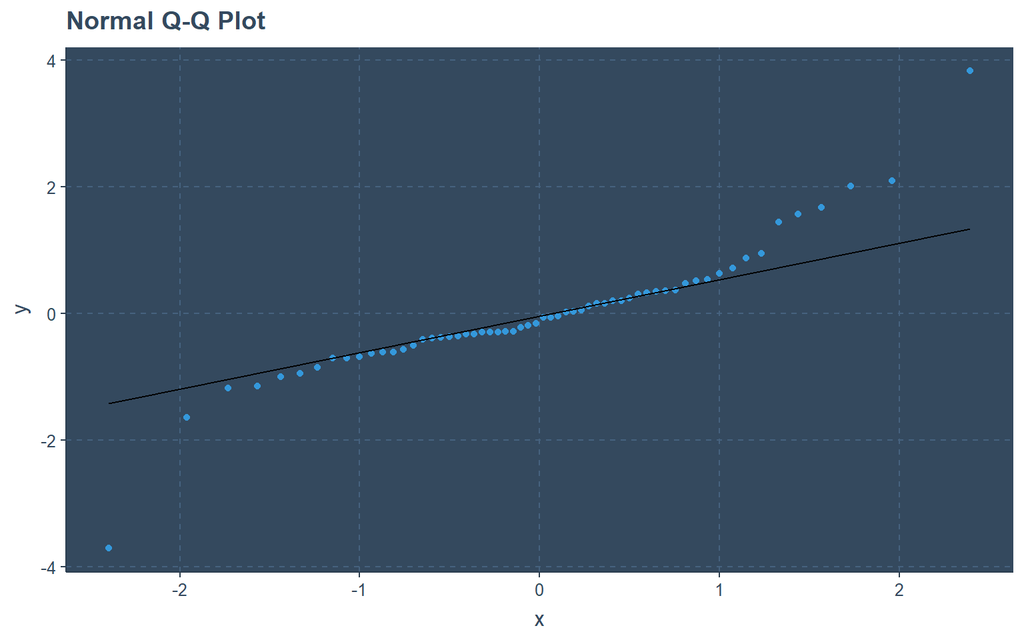

```r
# QQ-plot of residuals
ggplot(full_model, aes(sample = .stdresid)) +
  stat_qq() +
  stat_qq_line() +
  labs(title = "Normal Q-Q Plot")
```

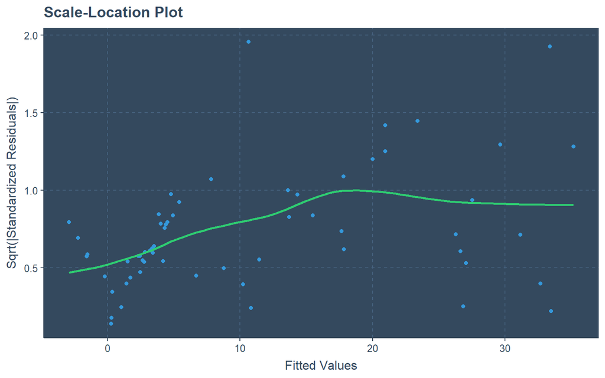

```r
# scale location plot
ggplot(full_model, aes(.fitted, sqrt(abs(.stdresid)))) +
  geom_point() +
  geom_smooth(se = FALSE) +
  labs(x = "Fitted Values", y = "Sqrt(|Standardized Residuals|)", title = "Scale-Location Plot")
```

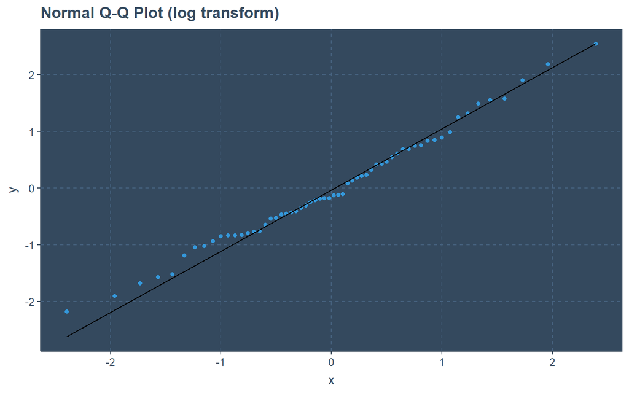

```r
# doing a log transform on the full model
logFull <- lm(log(bloodtol) ~ newppm + weight + age + snout_f, data = data)

# qq-plot
ggplot(logFull, aes(sample = .stdresid)) +
  stat_qq() +
  stat_qq_line() +
  labs(title = "Normal Q-Q Plot (log transform)")
```

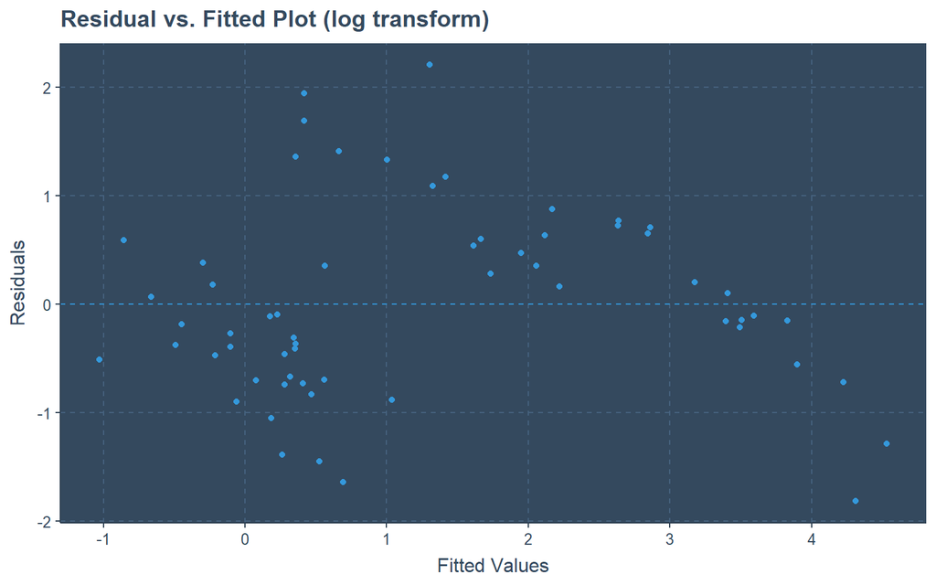

```r
# residuals plot
ggplot(logFull, aes(.fitted, .resid)) +
  geom_point() +
  geom_hline(yintercept = 0, linetype = "dashed") +
  labs(x = "Fitted Values", y = "Residuals", title = "Residual vs. Fitted Plot (log transform)")
```

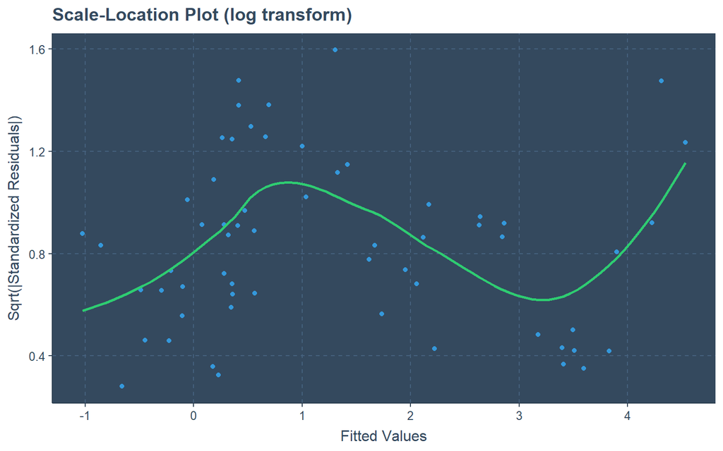

```r
# scale location plot
ggplot(logFull, aes(.fitted, sqrt(abs(.stdresid)))) +
  geom_point() +
  geom_smooth(se = FALSE) +
  labs(x = "Fitted Values", y = "Sqrt(|Standardized Residuals|)", title = "Scale-Location Plot (log transform)")
```

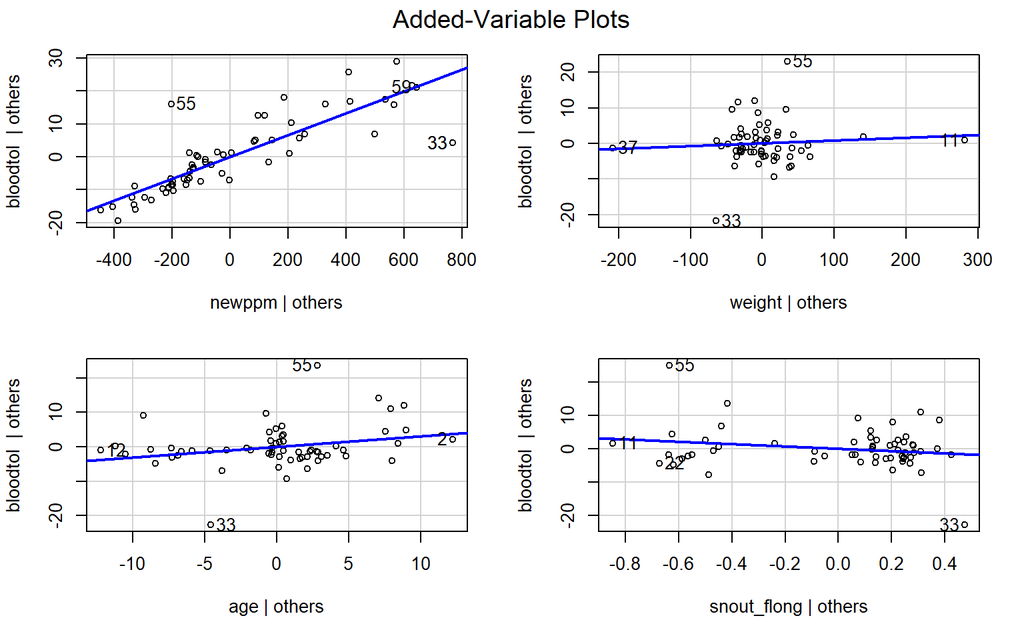

```r
avPlots(full_model)
```

**Which model did you choose? Why? Are you worried about any assumptions**  
Based on my own (hopefully sound) intuition, as well as the results from the VIF tests, I have decided to go with the full model including all covariates.  
I believe it intuitively makes sense that age and weight would play a role in how much toluene is in the bloodstream, and snout size could be important as to how much actually gets absorbed into the body.  
I also believe it makes intuitive sense that none of these variables would have much of heavy influence on each other or be strongly correlated.  
It is concerning that the residuals have a pattern in the plot corresponding with the newppm variable, as this is the most important factor in blood toluene levels. While similar to the residuals qq-plot in the model just including newppm, the plot using the full model appears very slightly more normal than the former. All of this could indicate a potential non-linear relationship requiring transformation. A log transform on blood toluene indeed shows more normal residuals, but it also shows a much less horizontal line in the scale-location plot.

# Part 6) Identifying Influential or Outlier Points

**Based on the model you chose in part 5, identify poorly fit, high leverage points, and/or influential points in your model.** **Comment on how you identified these particular points (based on which metric(s)?).**

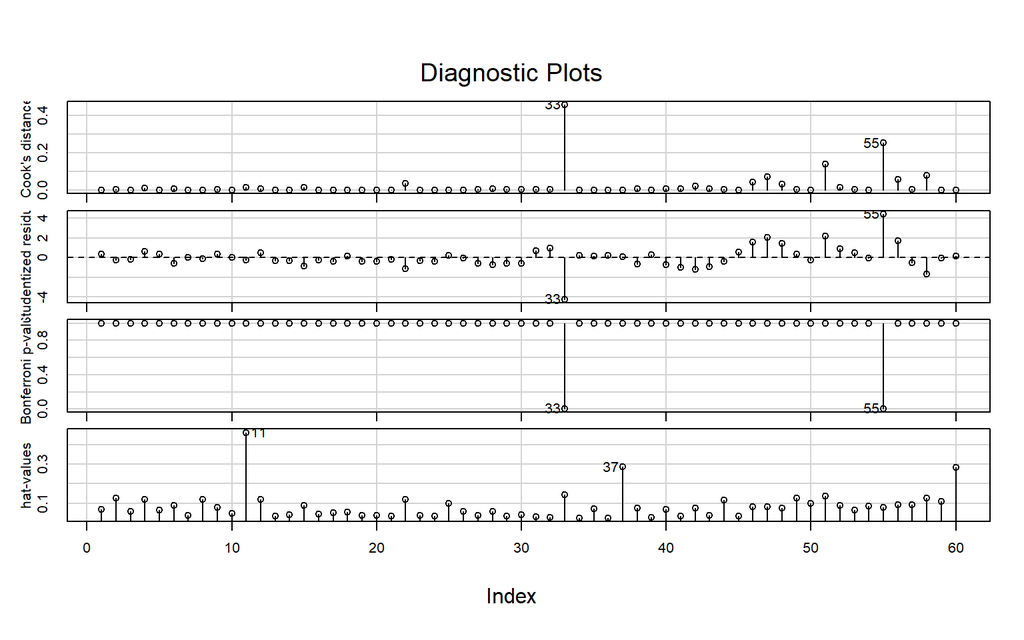

```r
# the influence index plotting functions from the `car` (such as influenceIndexPlot()) may be useful to spot these points
influenceIndexPlot(full_model)
```

# Part 7) Sensitivity to Outliers/Influential Points

**Perform a sensitivity analysis by refitting the model excluding the troublesome points in part 6. Is your model sensitive to these points?**

```r
# fit model removing outlier/influential points
# you can create a new data frame with the points remove or input the filtering in the lm() function
# for examplem if I wanted to remove the second and tenth rows I could run: lm(y ~ x1 + x2, data = mydata %>% slice(-c(2,10)))
# the slice() function grabs or removes (if included with a `-` sign) rows by their index
dataClean <- data %>%
  slice(-c(11, 27, 33, 55))

modelClean <- lm(bloodtol ~ newppm + weight + age + snout_f, data = dataClean)

# showing results
summary(modelClean)
```

```
##
## Call:
## lm(formula = bloodtol ~ newppm + weight + age + snout_f, data = dataClean)
##
## Residuals:
##     Min      1Q  Median      3Q     Max
## -9.8679 -2.1318 -0.6386  1.6518 11.7309
##
## Coefficients:
##               Estimate Std. Error t value Pr(>|t|)
## (Intercept) -13.941114  10.530972  -1.324   0.1915
## newppm        0.038263   0.002153  17.770   <2e-16 ***
## weight       -0.010411   0.013285  -0.784   0.4369
## age           0.203607   0.107183   1.900   0.0631 .
## snout_flong   0.969478   1.829679   0.530   0.5985
## ---
## Signif. codes:  0 '***' 0.001 '**' 0.01 '*' 0.05 '.' 0.1 ' ' 1
##
## Residual standard error: 4.341 on 51 degrees of freedom
## Multiple R-squared:  0.8892, Adjusted R-squared:  0.8805
## F-statistic: 102.3 on 4 and 51 DF,  p-value: < 2.2e-16
```

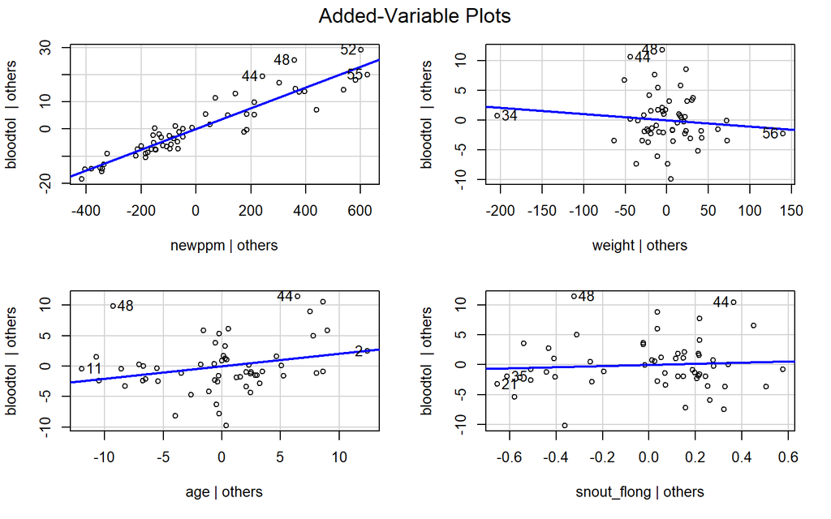

```r
avPlots(modelClean)
```

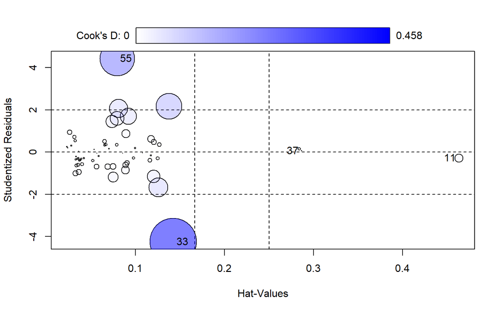

```
##        StudRes        Hat        CookD
## 11 -0.28769762 0.46325756 0.0145299087
## 33 -4.24416254 0.14259609 0.4576025856
## 37  0.05673578 0.28647789 0.0002632515
## 55  4.42447248 0.07937806 0.2523474585
```

```r
influencePlot(full_model)
```

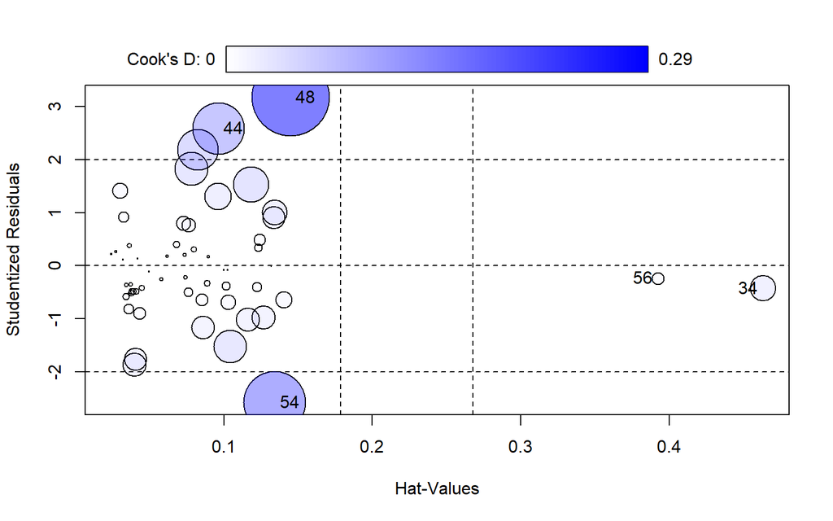

```
##       StudRes        Hat       CookD
## 34 -0.4261957 0.46314713 0.031852032
## 44  2.5843492 0.09635274 0.128158254
## 48  3.1716091 0.14493492 0.289570632
## 54 -2.5746760 0.13431952 0.185262828
## 56 -0.2372247 0.39221712 0.007400132
```

```r
influencePlot(modelClean)
```

```r
# comparing the two models
glance_full <- broom::glance(full_model)
glance_filtered <- broom::glance(modelClean)

# Comparing coefficients of the models
tidy_full <- broom::tidy(full_model)
tidy_filtered <- broom::tidy(modelClean)

glance_comparison <- bind_rows(glance_full, glance_filtered)
tidy_comparison <- bind_rows(tidy_full, tidy_filtered)

knitr::kable(glance_comparison)
```

| r.squared | adj.r.squared | sigma | statistic | p.value | df | logLik | AIC | BIC | deviance | df.residual | nobs |
| --- | --- | --- | --- | --- | --- | --- | --- | --- | --- | --- | --- |
| 0.7748646 | 0.7584911 | 6.201280 | 47.32436 | 0 | 4 | -192.0113 | 396.0226 | 408.5887 | 2115.0731 | 55 | 60 |
| 0.8891635 | 0.8804704 | 4.340679 | 102.28428 | 0 | 4 | -159.0516 | 330.1031 | 342.2552 | 960.9161 | 51 | 56 |

```r
knitr::kable(tidy_comparison)
```

| term | estimate | std.error | statistic | p.value |
| --- | --- | --- | --- | --- |
| (Intercept) | -25.1906374 | 14.2830945 | -1.7636680 | 0.0833419 |
| newppm | 0.0331143 | 0.0027318 | 12.1215597 | 0.0000000 |
| weight | 0.0078489 | 0.0139483 | 0.5627148 | 0.5759157 |
| age | 0.3125911 | 0.1508750 | 2.0718558 | 0.0429812 |
| snout_flong | -3.3974975 | 2.2743753 | -1.4938157 | 0.1409390 |
| (Intercept) | -13.9411137 | 10.5309720 | -1.3238202 | 0.1914661 |
| newppm | 0.0382632 | 0.0021533 | 17.7696631 | 0.0000000 |
| weight | -0.0104113 | 0.0132854 | -0.7836684 | 0.4368592 |
| age | 0.2036073 | 0.1071825 | 1.8996316 | 0.0631434 |
| snout_flong | 0.9694779 | 1.8296794 | 0.5298622 | 0.5985068 |

The new model with the troublesome points removed has a higher adjusted R2 **(0.88 vs 0.76)** and very different coefficients for weight and snout size, to the point that they change direction. Sigma decreased in the filteread model as well. All this indicates that the model was indeed very sensitive to these points.

# Part 8) Robust Regression

**Fit a robust regression using the model you chose in part 5 and compare the two models. Comment on the differences. Do you think the robust model is more appropriate here?**

```r
# fit robust regression model (rlm() funciton from `MASS` package)
modelRobust <- rlm(bloodtol ~ newppm + weight + age + snout_f, data = data)

# showing summaries of the two models again
summary(modelRobust)
```

```
##
## Call: rlm(formula = bloodtol ~ newppm + weight + age + snout_f, data = data)
## Residuals:
##      Min       1Q   Median       3Q      Max
## -23.4522  -1.7244  -0.4215   1.8844  25.5379
##
## Coefficients:
##             Value    Std. Error t value
## (Intercept) -12.3493   8.1736    -1.5109
## newppm        0.0358   0.0016    22.8762
## weight       -0.0006   0.0080    -0.0775
## age           0.1561   0.0863     1.8079
## snout_flong  -0.6022   1.3015    -0.4627
##
## Residual standard error: 2.578 on 55 degrees of freedom
```

```r
summary(full_model)
```

```
##
## Call:
## lm(formula = bloodtol ~ newppm + weight + age + snout_f, data = data)
##
## Residuals:
##      Min       1Q   Median       3Q      Max
## -21.2982  -2.5936  -0.6433   2.0629  22.7613
##
## Coefficients:
##               Estimate Std. Error t value Pr(>|t|)
## (Intercept) -25.190637  14.283095  -1.764   0.0833 .
## newppm        0.033114   0.002732  12.122   <2e-16 ***
## weight        0.007849   0.013948   0.563   0.5759
## age           0.312591   0.150875   2.072   0.0430 *
## snout_flong  -3.397497   2.274375  -1.494   0.1409
## ---
## Signif. codes:  0 '***' 0.001 '**' 0.01 '*' 0.05 '.' 0.1 ' ' 1
##
## Residual standard error: 6.201 on 55 degrees of freedom
## Multiple R-squared:  0.7749, Adjusted R-squared:  0.7585
## F-statistic: 47.32 on 4 and 55 DF,  p-value: < 2.2e-16
```

```r
coeff_full <- summary(full_model)$coefficients
coeff_robust <- summary(modelRobust)$coefficients

# making data.frame comparing the results
comparison_df <- data.frame(
  Term = rownames(coeff_full),
  Full_Model_Estimate = coeff_full[, "Estimate"],
  Robust_Model_Estimate = coeff_robust[, "Value"],
  Difference = coeff_full[, "Estimate"] - coeff_robust[, "Value"]
)

knitr::kable(comparison_df)
```

|  | Term | Full_Model_Estimate | Robust_Model_Estimate | Difference |
| --- | --- | --- | --- | --- |
| (Intercept) | (Intercept) | -25.1906374 | -12.3492994 | -12.8413380 |
| newppm | newppm | 0.0331143 | 0.0357627 | -0.0026485 |
| weight | weight | 0.0078489 | -0.0006188 | 0.0084677 |
| age | age | 0.3125911 | 0.1560909 | 0.1565003 |
| snout_flong | snout_flong | -3.3974975 | -0.6021871 | -2.7953104 |

From this comparison, we can see that:

The intercept has a large difference, which indicates that the baseline level predicted by the two models varies considerably.  
The coefficient for **newppm is slightly higher in the robust model**, but the difference is relatively small.  
The **weight coefficient changes sign** between the two models, which could indicate that this variable’s influence is quite sensitive to outliers or leverage points.  
The **age coefficient is about half** in the robust model compared to the full model, suggesting that the effect of age is less pronounced when the influence of outliers is mitigated.  
The **snout_flong coefficient has the most significant change in magnitude**, showing a drastic reduction in the robust model, which implies that the full model’s estimate for this term may be highly influenced by outliers.

# Part 9) Data Transformations

**Based on what you saw in your descriptives from part 1 and the residual plots from your final model would a data transformation be appropriate? If so which one? (no need to transform, just comment).**

I believe a data transformation would be appropriate. As was seen earlier, the residuals do not seem to be randomly scattered around the horizontal line in the residual vs fitted plot and, instead, show some pattern(s). This could help more clearly satisfy the assumptions of linear regression. Additionally, using transformations could mitigate the effect of some of the outliers, making the non-robust model more appropriate to use.

# Part 10) Summary

**Summarize your findings from parts 1-9** **(model chosen, trends found using said model, possible multicollinearity, sensitivity to outliers/influential points, etc.)**

The model that we chose involved using all the covariates based on intuition that they all probably have an effect on the outcome and that they showed no strong signs of collinearity. The model showed sensitivity to outliers, causing us to choose a robust regression model as the likely more appropriate model. In the robust and non-robust models, some of the variables drastically differed, as seen in the table in part 8.